title: “Series01-RStudio” author: “Baptiste Augros” date: “23 September, 2025, 14:31” output: html_document: df_print: paged code_folding: hide toc: false number_sections: true

```r
ieap2025 <- read.csv("data/DataIEAPStudents.csv")
head(ieap2025)
```

```
##   Name Firstname BornMonth BornYear Weight Height Gender YearsInR YearsInPython
## 1  Gra       Mar         6     2002     50    160      F        1             1
## 2  Loc       Jea         5     2001     70    178      M        1             1
## 3  Pen       Mar         6     2002     84    182      M        0             0
## 4  Biw       Bie         2     1980     84    178      M        0             0
## 5  Sam       Mar         4     2002     63    167      F        0             0
## 6  Pon       Lea         5     2001     58    163      F        0             0
##   YearsInResearch          City            Lab
## 1               1   Montpellier        EuroMov
## 2               1   Montpellier        EuroMov
## 3               1      Toulouse           U528
## 4               3 Saint Etienne BioMontpellier
## 5               0   Montpellier           None
## 6               0   Montpellier        Epsylon
```

# Load the data file

The data is from https://docs.google.com/spreadsheets/d/1AZvf5EuWStJ-gfY8z_AKUS2i5lRqNUyYWuTTx-pJe2Y/edit?gid=0#gid=0

# Make a histogram of the Weight of the students

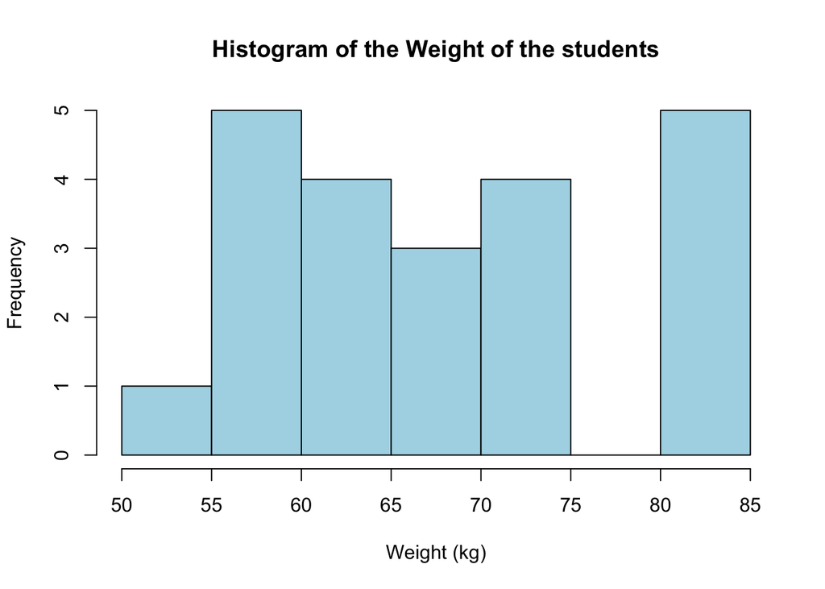

```r
# With R base
hist(ieap2025$Weight,
     main = "Histogram of the Weight of the students",
     xlab = "Weight (kg)",
     col = "lightblue",
     border = "black",
     breaks = 10)  # nombre de classes
```

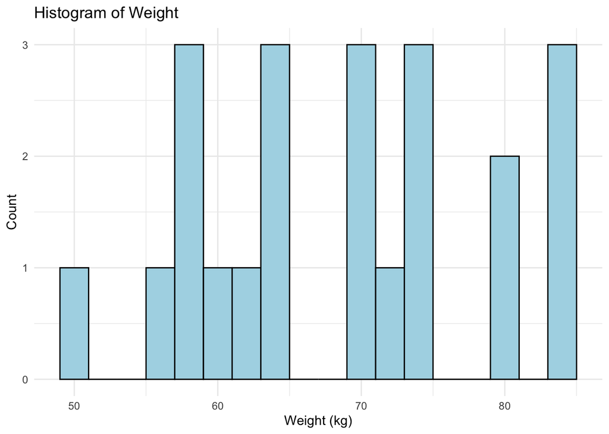

```r
# With ggplot2
library(ggplot2)

ggplot(ieap2025, aes(x = Weight)) +
  geom_histogram(binwidth = 2, fill = "lightblue", color = "black") +
  labs(title = "Histogram of Weight",
       x = "Weight (kg)",
       y = "Count") +
  theme_minimal()
```

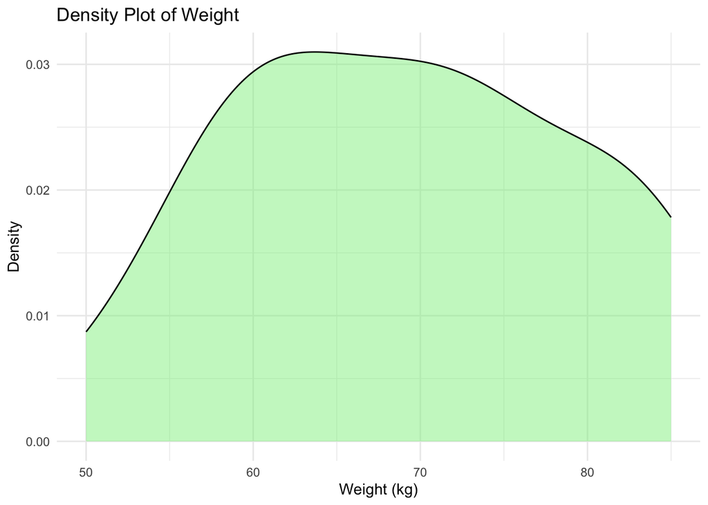

[figure not shown]

```r
# With R base
ggplot(ieap2025, aes(x = Weight)) +
  geom_density(fill = "lightgreen", alpha = 0.5) +
  labs(title = "Density Plot of Weight",
       x = "Weight (kg)",
       y = "Density") +
  theme_minimal()
```

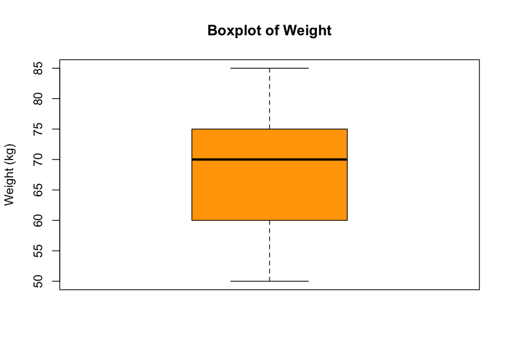

```r
# With R base
boxplot(ieap2025$Weight,
        main = "Boxplot of Weight",
        ylab = "Weight (kg)",
        col = "orange",
        border = "black")
```

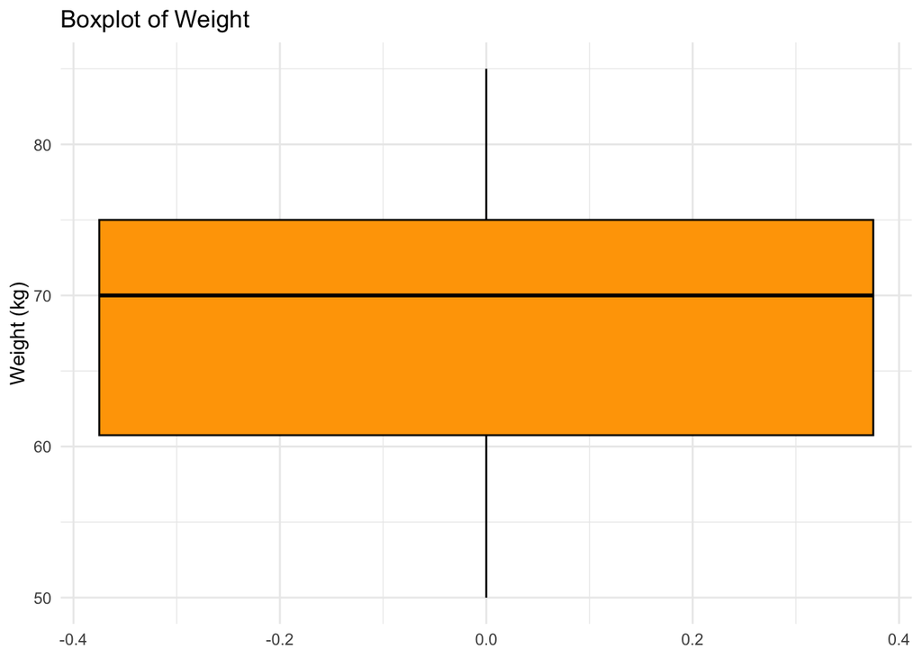

```r
# With ggplot2
ggplot(ieap2025, aes(y = Weight)) +
  geom_boxplot(fill = "orange", color = "black") +
  labs(title = "Boxplot of Weight",
       y = "Weight (kg)") +
  theme_minimal()
```

### 3.3 Boxplot to summarize the distribution

- **Main elements of a boxplot:**
  - Median (Q2) → line inside the box
  - First quartile (Q1, 25th percentile) → bottom edge of the box
  - Third quartile (Q3, 75th percentile) → top edge of the box
  - Interquartile range (IQR = Q3 − Q1) → spread of the middle 50% of data
  - Whiskers → extend to smallest/largest values within 1.5 × IQR
  - Outliers → points beyond the whiskers
- **Why start with a boxplot for an unknown distribution:**
  - Summarizes key statistics (median, quartiles, spread, extremes)
  - Shows asymmetry or skewness in the data
  - Detects potential outliers
  - Compact summary suitable for small or large datasets
  - Requires no assumptions about the distribution (robust for unknown distributions)
- **References for further reading:**
  - [Boxplot – Wikipedia](https://en.wikipedia.org/wiki/Box_plot)
  - [Understanding Boxplots – Towards Data Science](https://towardsdatascience.com/understanding-boxplots-5e2df7bcbd51)
  - [R Boxplot Documentation](https://www.rdocumentation.org/packages/graphics/versions/3.6.2/topics/boxplot)

# Make a scatter plot of Height vs Weight

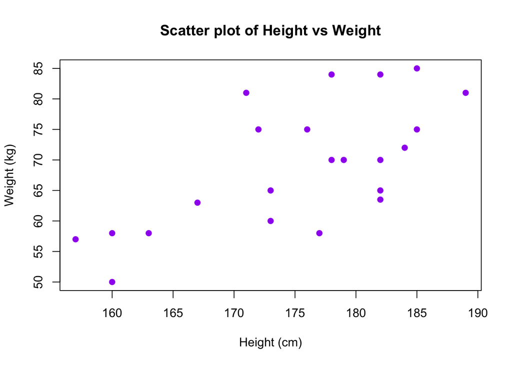

```r
      plot(ieap2025$Height, ieap2025$Weight
     , main = "Scatter plot of Height vs Weight"
     , xlab = "Height (cm)"
     , ylab = "Weight (kg)"
     , col = "purple"
     , pch = 19)
```

# 4. Ask real questions as a scientist.

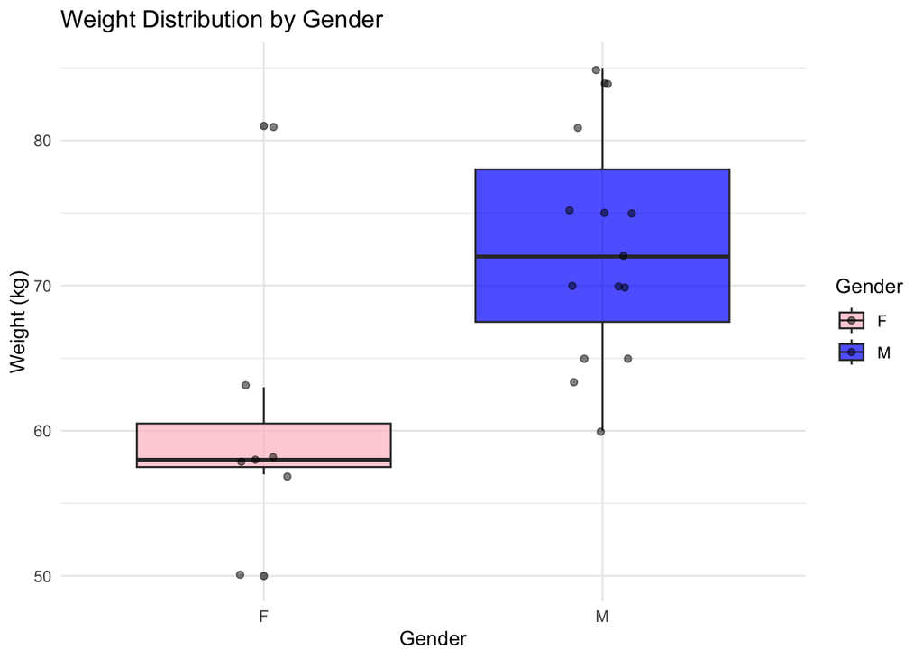

```r
library(ggplot2)

ggplot(ieap2025, aes(x = Gender, y = Weight, fill = Gender)) +
  geom_boxplot(alpha = 0.7) +
  geom_jitter(width = 0.1, alpha = 0.5) +
  labs(title = "Weight Distribution by Gender",
       x = "Gender",
       y = "Weight (kg)") +
  scale_fill_manual(values = c("M" = "blue", "F" = "pink")) +
  theme_minimal()
```

# Explanations about the distribution :

1️⃣ Male vs Female distribution comparison.

2️⃣ Professional Graph

Boxplot with individual points by gender: shows median, quartiles, outliers, and spread. Improve analysis (on my mind). Use distinct colors for more readability : blue for males and pink for females (quite stereotypics but easy to understand).

3️⃣ Ideal Graph

Fore me, a graph needs to be clear, readable and informative. A histogram can show overall shape, but is less precise for comparing groups.

4️⃣ Let’s try to plot an histogram and decide what is prefered ! # Make a histogram of the Weight separating Males and Females

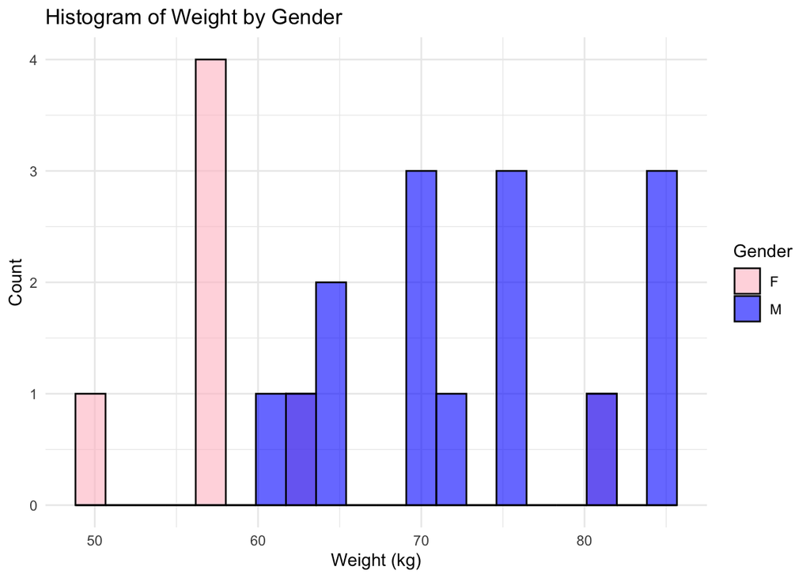

```r
# Histogram of weight distribution by gender

ggplot(ieap2025, aes(x = Weight, fill = Gender)) +
  geom_histogram(position = "identity", alpha = 0.6, bins = 20, color = "black") +
  labs(title = "Histogram of Weight by Gender",
       x = "Weight (kg)",
       y = "Count") +
  theme_minimal() +
  scale_fill_manual(values = c("M" = "blue", "F" = "pink"))
```

Works but boxplot is preferred for comparing male vs female distributions.

# 4.1 Is the weight of males/females significantly different?

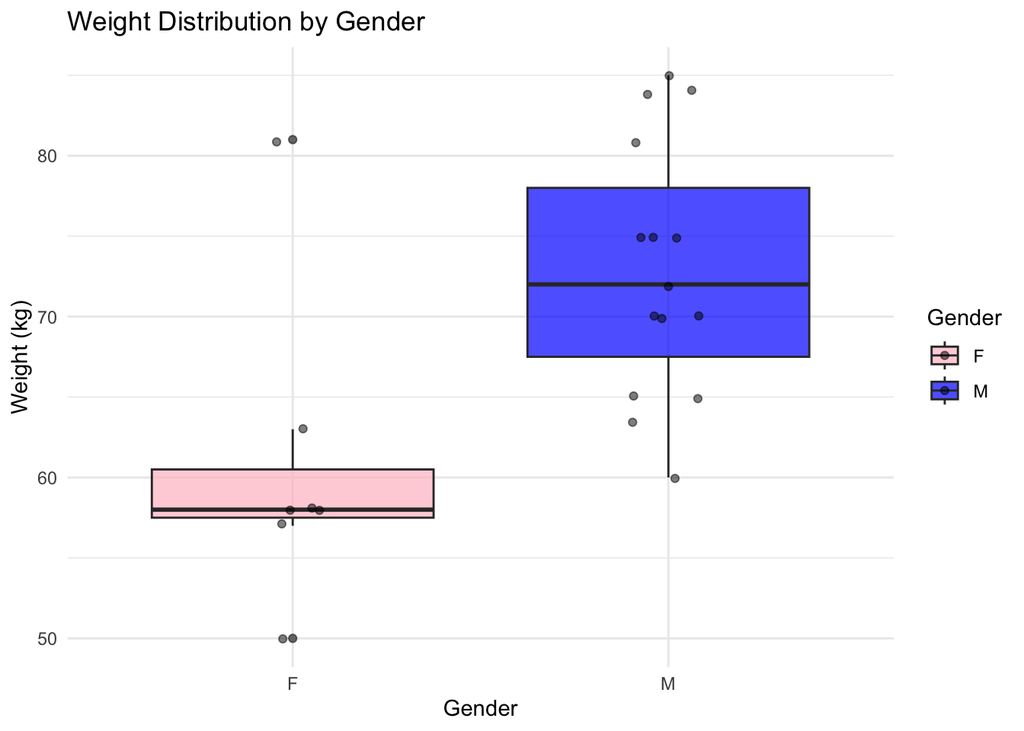

```r
library(tidyverse)

# Boxplot with points
ggplot(ieap2025, aes(x = Gender, y = Weight, fill = Gender)) +
  geom_boxplot(alpha = 0.7) +
  geom_jitter(width = 0.1, alpha = 0.5) +
  labs(title = "Weight Distribution by Gender",
       x = "Gender",
       y = "Weight (kg)") +
  scale_fill_manual(values = c("M" = "blue", "F" = "pink")) +
  theme_minimal()
```

```r
# t-test comparing male vs female weights
t_test_result <- t.test(Weight ~ Gender, data = ieap2025)
t_test_result
```

```
##
##  Welch Two Sample t-test
##
## data:  Weight by Gender
## t = -2.9133, df = 9.8792, p-value = 0.01566
## alternative hypothesis: true difference in means between group F and group M is not equal to 0
## 95 percent confidence interval:
##  -21.638713  -2.866049
## sample estimates:
## mean in group F mean in group M
##        60.71429        72.96667
```

```r
# Calculate effect size (r) from t-test
t_value <- t_test_result$statistic
df <- t_test_result$parameter
r <- sqrt(t_value^2 / (t_value^2 + df))

# Automatic conclusion based on p-value
if(t_test_result$p.value < 0.05){
  cat("Conclusion: There is a statistically significant difference between male and female weights (p =", round(t_test_result$p.value,3),
      "), and the effect of gender is large (r =", round(r,2), ").\n")
} else {
  cat("Conclusion: There is no statistically significant difference between male and female weights (p =", round(t_test_result$p.value,3), ").\n")
}
```

```
## Conclusion: There is a statistically significant difference between male and female weights (p = 0.016 ), and the effect of gender is large (r = 0.68 ).
```